# HW4: Random Effects + Into to Factorial Designs

MATH/STAT 571B

DUE: 3/22/2024 11:59pm

## Homework Guidelines

*Please submit your answers on Gradescope as a PDF with pages matched to question answers.*

One way to prepare your solutions to this homework is with R Markdown, which provides a way to include mathematical notation, text, code, and figures in a single document. A template `.Rmd` file is available through D2L.

Make sure all solutions are clearly labeled, and please utilize the question pairing tool on Gradescope. You are encouraged to work together, but your solutions, code, plots, and wording should always be your own. Come and see me during office hours or schedule an appointment when you get stuck and can’t get unstuck.

### I. Mathematical Foundations [13 pts]

1. [7 pts] Suppose we are running a single-factor experiment with $a$ levels modeled by $y_{ij} = \mu_i + \epsilon_{ij}, \; \epsilon_{ij} \sim \mathrm{N}(0, \sigma^2)$ and are interested in testing $H_0\!: \mu_i = 0, \; i = 1, \dots, a$ using the usual $F$-statistic. We know that the power of the test depends directly on the “between variance”, $V_b = \frac{1}{a} \sum_{i=1}^a(\mu_i - \bar\mu)^2$, and that power increases monotonically with increasing $V_b$ (i.e., the more spread out the group means are, the more power we will we will have to reject $H_0$). We would like to calculate the minimum power of our test under the assumption that at least one pair of means differs by an amount $D$ (i.e., $|\mu_i - \mu_j| = D$ for some $i, j$). Thus, we need to know the minimum possible value of $V_b$ consistent with our assumption.

   Without loss of generality, assume that the index $i$ on the means corresponds to a sorted, non-decreasing order such that $\mu_1 \leq \mu_2 \leq \dots \leq \mu_a$.
   1. [2 pts] Provide an argument for why $V_b$ is minimized when the absolute difference $|\mu_i - \mu_j| = D$ occurs between the largest and smallest means (i.e., $\mu_a - \mu_1 = D$).
   2. [3 pts] Show that $V_b$ is minimized when $\mu_i= \bar\mu$ for all $1 < i < a$. That is, the smallest value of $V_b$ occurs when all of the means besides $\mu_1$ and $\mu_a$ are equal to $\bar\mu = \frac{1}{a}\sum_{i = 1}^a \mu_i$.
   3. [2 pts] Show that the minimum value for $V_b$ is $\frac{D^2}{2a}$.

   Assume that the results of the coffee experiment are expected to be shared with all faculty in the Statistics GIDP to help them optimize their coffee intake. Determine whether each factor should be treated as a fixed or random effect and explain your reasoning. **(Cafe) and (Time of Day) should be considered fixed effects because the levels can be set. The choice of cafe and the time of day can be set for repeated experiments in the future, and we do care about the possible cafe effect on the coffee. (Faculty member) should be considered a random effect because future experiments may not be able to choose the exact same faculty members, and they can be assumed to come from some normal population with some standard deviation. The levels are not as important since the coffee testers are not a factor for which you can set levels.**

### II. Applications [27 pts]

3. [7 pts] (DAE 5.1)
   1. [3 pts] *Give exact p-values*.

   DF values - A: 1 df, B = AB interaction: 2 df (since ab_df = b_df * a_df and a_df = 1)

   SS interaction - 45.348

   MS values - A: 0.322, AB interaction: 22.674

   F values - A: 0.03668554, AB interaction: 2.58325453

   p values - A:0.8513093, B:0.03307743, AB interaction: 0.1166798

```r
# DF
leftover_df <- 17 -12 - 1
leftover_df / 2
```

```
## [1] 2
```

```r
# SS (orthogonal since factorial design)
ss_interaction <- 231.551 - 105.327 - 80.554 - 0.322
ss_interaction
```

```
## [1] 45.348
```

```r
# MS
ss_interaction /2
```

```
## [1] 22.674
```

```r
# F values
f_A <- 0.322 / 8.7773
f_AB <- 22.674 / 8.7773
c(f_A, f_AB)
```

```
## [1] 0.03668554 2.58325453
```

```r
# p values
pf(f_A, 1, 12, lower.tail=F)
```

```
## [1] 0.8513093
```

```r
f_B <- 4.59
pf(f_B, 2, 12, lower.tail=F)
```

```
## [1] 0.03307743
```

```r
pf(f_AB, 2, 12, lower.tail=F)
```

```
## [1] 0.1166798
```

```
(b) [1 pts] There are 3 levels for factor B (since B has 2 df)
(c) [1 pts] 18 / 6 = 3 replicates
(d) [2 pts] Based on the p-values, it appears that factor B has a significant effect on the response at a 0.05 alpha level. It has a p-value of 0.033 which would be lower than an alpha = 0.05. At least one level varies significantly from the others in factor B.
```

4. [6 pts] (DAE 5.6)

```r
tv <- read.csv("./Datasets/Q5-6.csv")
tv$Phosphorous <- as.factor(tv$Phosphorous)
tv$Glass <- as.factor(tv$Glass)
tv_aov <- aov(Current ~ Phosphorous*Glass, data=tv)
summary(tv_aov)
```

```
##                   Df Sum Sq Mean Sq F value   Pr(>F)
## Phosphorous        2    933     467   8.842  0.00436 **
## Glass              1  14450   14450 273.789 1.26e-09 ***
## Phosphorous:Glass  2    133      67   1.263  0.31780
## Residuals         12    633      53
## ---
## Signif. codes:  0 '***' 0.001 '**' 0.01 '*' 0.05 '.' 0.1 ' ' 1
```

[output not shown]

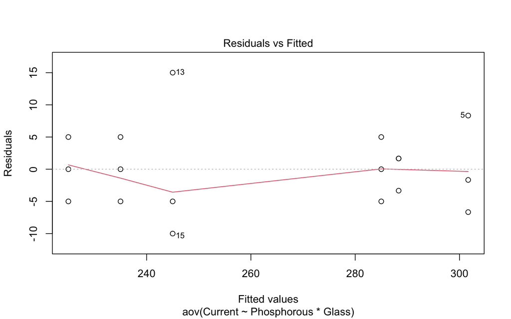

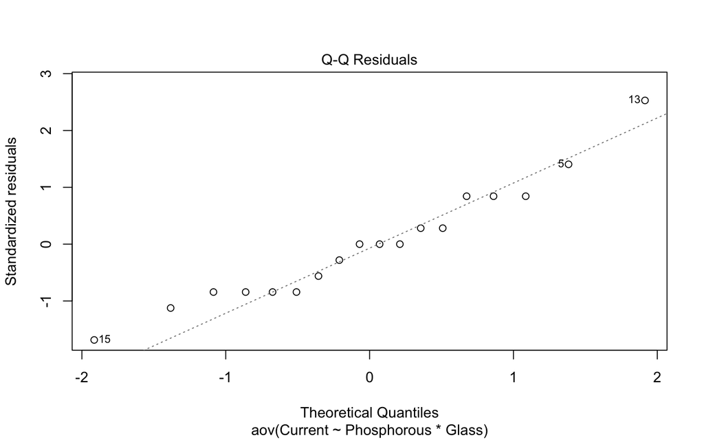

```r
plot(tv_aov, c(1,2))
```

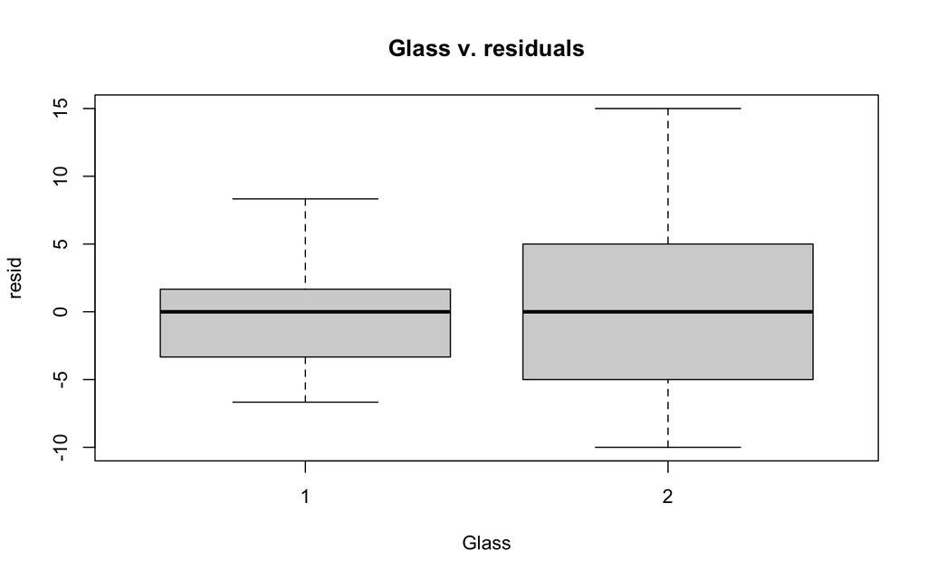

```r
plot(tv
     $Glass, resid(tv_aov), main = 'Glass v. residuals', xlab='Glass', ylab='resid')
```

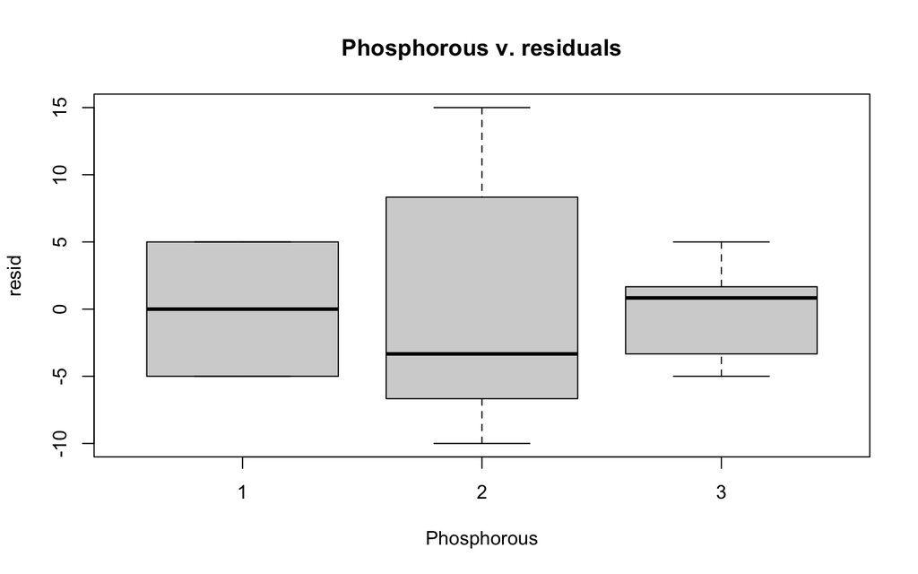

```r
plot(
  tv$Phosphorous,
  resid(tv_aov),
  main = 'Phosphorous v. residuals',
  xlab = 'Phosphorous',
  ylab = 'resid'
)
```

```r
adhesive <- read.csv("./Datasets/Q5-16.csv")
adhesive$Pressure <- as.factor(adhesive$Pressure)
adhesive$Temperature <- as.factor(adhesive$Temperature)

adhesive_aov <- aov(Strength ~ Pressure + Temperature, data = adhesive)
adhesive$q <- adhesive_aov$fitted.values^2
adhesive_tukey_add <- aov(Strength ~ Pressure + Temperature + q, data = adhesive)
summary(adhesive_tukey_add)
```

```
##             Df Sum Sq Mean Sq F value Pr(>F)
## Pressure     3  0.581  0.1936   0.581 0.6524
## Temperature  2  4.658  2.3288   6.996 0.0356 *
## q            1  0.489  0.4895   1.470 0.2794
## Residuals    5  1.664  0.3329
## ---
## Signif. codes:  0 '***' 0.001 '**' 0.01 '*' 0.05 '.' 0.1 ' ' 1
```

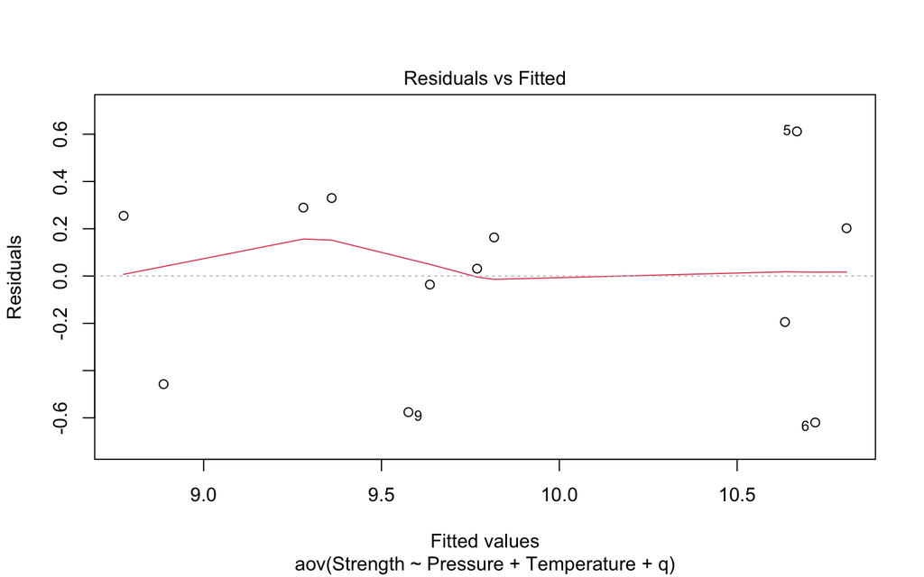

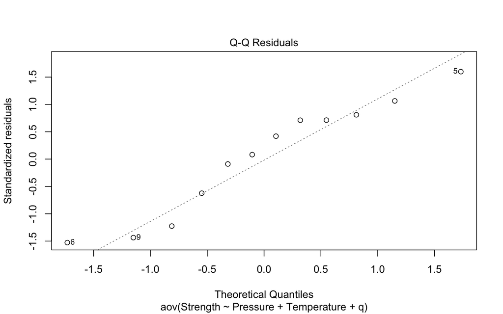

```r
# Model assumptions
plot(adhesive_tukey_add, c(1,2))
```

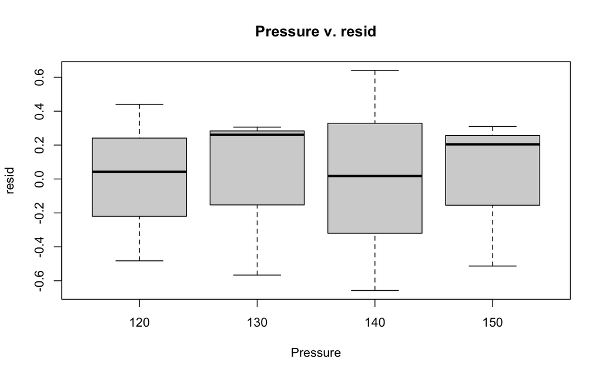

```r
plot(adhesive$Pressure, resid(adhesive_aov), xlab="Pressure", ylab="resid", main="Pressure v. resid")
```

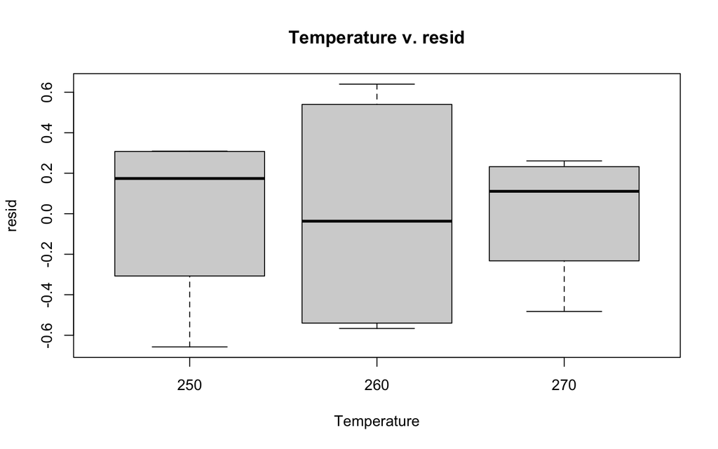

```r
plot(adhesive$Temperature, resid(adhesive_aov), xlab="Temperature", ylab="resid", main="Temperature v. resid")
```

6. [7 pts] (DAE 5.21) *Perform your analysis assuming Day is a random effect. Your analysis should include: relevant tests for each main effect and their interaction, a test for the null hypothesis of zero random effect, and a check for violations of basic assumptions.*

At alpha = 0.05, both Temperature and Pressure appear to be significant factors with p-values 2.778e-06 and 0.03599, respectively. However, their interaction is not significant (p-value = 0.17331). The Day random effect also appears to be signficant at a p-value of 0.003851. The diagnostics reveal no violations to the basic assumptions (qq plot shows normal residuals and residual plots (against fitted, temperature, pressure, day) indicate constant variance).

```r
library(lmerTest)
chemicals <- read.csv("./Datasets/Q5-21.csv")
chemicals$Pressure <- as.factor(chemicals$Pressure)
chemicals$Day <- as.factor(chemicals$Day)
chemicals$Temperature <- as.factor(chemicals$Temperature)

chemicals_RE <- lmer(Yield ~ Pressure * Temperature + (1 | Day), data = chemicals)
anova(chemicals_RE)
```

|  | Sum Sq | Mean Sq | NumDF | DenDF | F value | Pr(>F) |
| --- | --- | --- | --- | --- | --- | --- |
| Pressure | 5.507778 | 2.753889 | 2 | 8 | 5.183791 | 3.598753e-02 |
| Temperature | 99.854439 | 49.927220 | 2 | 8 | 93.980649 | 2.777658e-06 |
| Pressure:Temperature | 4.452222 | 1.113056 | 4 | 8 | 2.095163 | 1.733137e-01 |

```r
ranova(chemicals_RE)
```

|  | npar | logLik | AIC | LRT | Df | Pr(>Chisq) |
| --- | --- | --- | --- | --- | --- | --- |
|  | 11 | -14.64219 | 51.28437 | NA | NA | NA |
| (1 \| Day) | 10 | -18.81856 | 57.63711 | 8.352743 | 1 | 0.003851055 |

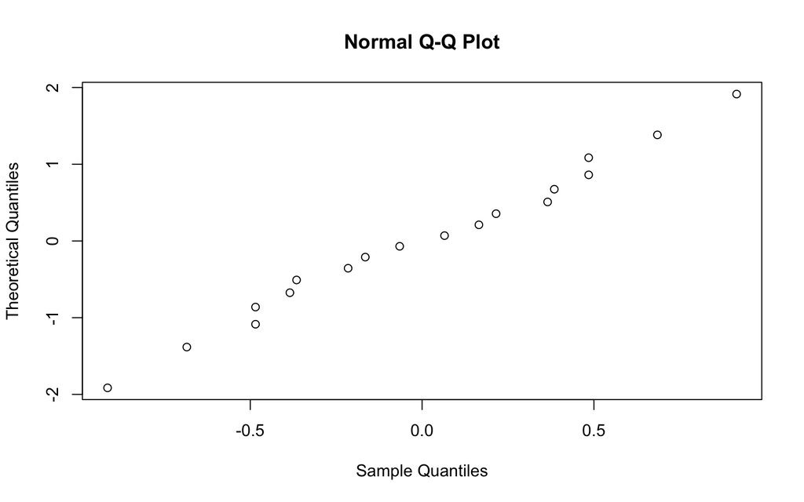

```r
# Check for model assumptions
resid <- resid(chemicals_RE)
qqnorm(resid, datax = T)
```

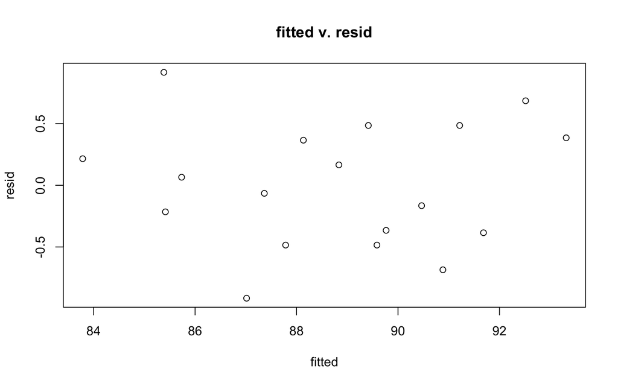

```r
plot(fitted(chemicals_RE), resid, main="fitted v. resid", xlab="fitted", ylab="resid")
```

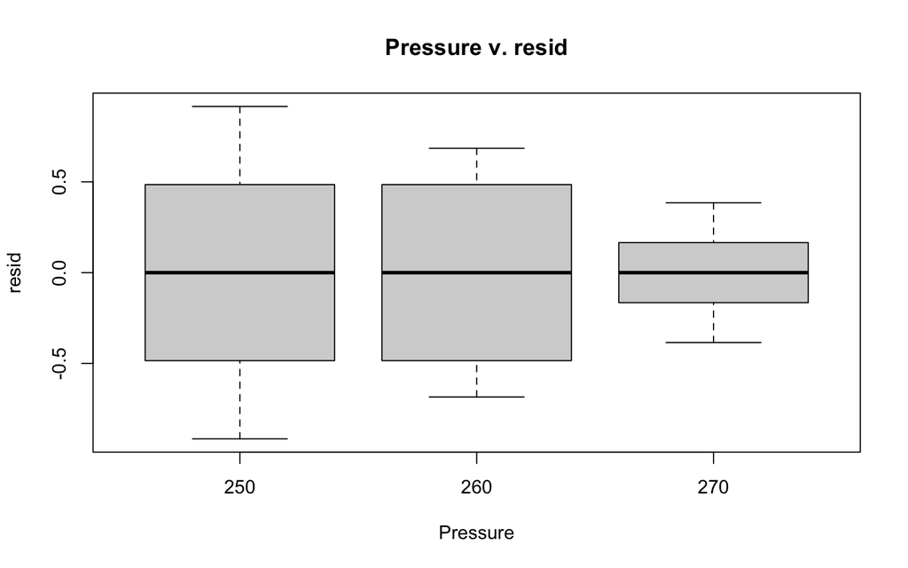

```r
plot(chemicals$Pressure, resid, main="Pressure v. resid", xlab="Pressure", ylab="resid")
```

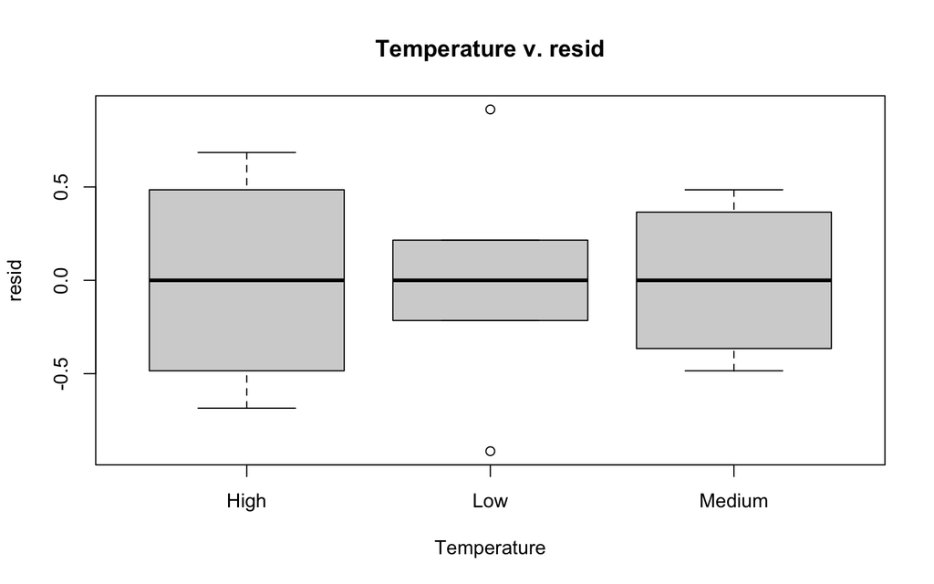

```r
plot(chemicals$Temperature, resid, main="Temperature v. resid", xlab="Temperature", ylab="resid")
```

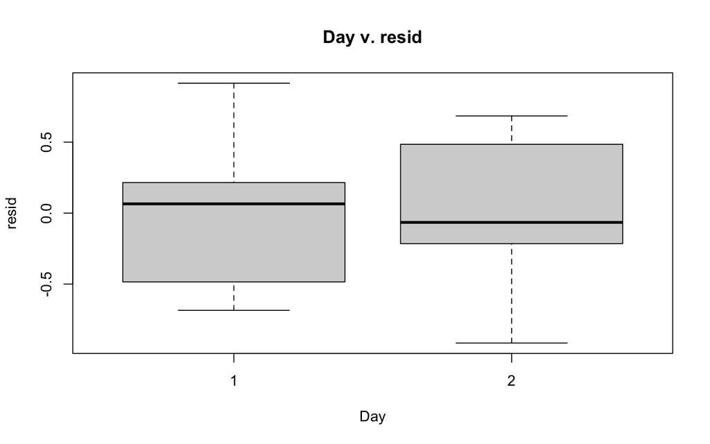

```r
plot(chemicals$Day, resid, main="Day v. resid", xlab="Day", ylab="resid")
```